# Practica 2

Analisis de Componentes principales

01 de abril de 2017

# 1 Introducción

Esta práctica puede descargarse en formato **pdf** en este **enlace**.

Se compone de tres ejercicios en los que se realiza un análisis de componentes principales con tres conjuntos de datos (**ventas**, **sctkp**, **dowjones**).

En estadística, el [**Análisis de Componentes Principales**](https://es.wikipedia.org/wiki/An%C3%A1lisis_de_componentes_principales) (en español *ACP*, en inglés, *PCA*) es una técnica utilizada para reducir la dimensionalidad de un conjunto de datos.

Técnicamente, el ACP busca la proyección según la cual los datos queden mejor representados en términos de mínimos cuadrados. Convierte un conjunto de observaciones de variables posiblemente correlacionadas en un conjunto de valores de variables sin correlación lineal llamadas componentes principales.

Los objetivos del Análisis de Componentes Principales son:

- Resumir la variación total en una **dimensión menor**.
- Identificar fuentes de variación **interpretables**.
- Explorar características **inesperadas** de los datos.

El ACP se emplea sobre todo en análisis exploratorio de datos y como herramienta de procesado inicial de los datos. El ACP comporta el cálculo de la descomposición en autovalores y autovectores de la matriz de covarianza, normalmente tras centrar los datos en la media de cada atributo. Las componentes principales están basadas en combinaciones lineales de los datos originales centrados $X-\bar{x}$

> Nota

> Esta web es un [R Notebook](http://rmarkdown.rstudio.com). Se ha desarrollado con el lenguaje Rmarkdown en **R-Studio**, que utiliza *knitr* y *pandoc* para exportar el código a varios formatos: *html, pdf, doc y md*. Es posible descargar el archivo *.Rmd* desde [github](https://github.com/xvilan/practicasADM) y ejecutar los scripts mediante R-Studio. Para ello es necesario tener instalados los paquetes:

```
install.packages("rmarkdown")
install.packages("installr")
install.packages("pandoc")
```

# 2 Ejercicio [1]

En este ejercicio se hace una descripción pormenorizada del proceso de ACP. En los sucesivos las explicaciones se simplificarán empleando sólo las funciones directas. Los resultados se redondearán, de manera general, a cuatro decimales.

## 2.1 Carga de datos

Se carga el archivo **ventas.txt** a R-Studio, indicando previamente a R-Studio cuál es el directorio de trabajo en el que estará localizado el archivo.

```r
ventas = read.table('ventas.txt');
show(ventas);
```

```
##          ventas beneficios activos
## G.M.       26.7        3.3    15.8
## Exxon      38.4        2.4    19.5
## Ford       19.2        1.7     8.4
## Mobil      20.6        1.0     8.2
## Texaco     18.9        0.9     9.4
## Std.Oil    14.8        1.0     7.6
## IBM        19.0        2.7    12.6
## Gulf       14.2        0.8     7.3
## G.E.       13.7        1.1     5.9
## Chrysler    7.7        0.2     2.9
```

A continuación, se realiza una exploración del contenido del dataset, como por ejemplo, consultar el número de filas y columnas o el tipo de tabla de datos creada. El número de filas, se consulta empleando la función *“nrow”*, y el tipo de archivo con la función *“class”*.

```r
n = nrow(ventas);
tipo_de_tabla = class(ventas);
n;
```

```
## [1] 10
```

```r
tipo_de_tabla;
```

```
## [1] "data.frame"
```

También pueden utilizarse otras funciones como *“str”*, que devuelve una descripción de la estructura de la tabla,

```r
str(ventas)
```

```
## 'data.frame':    10 obs. of  3 variables:
##  $ ventas    : num  26.7 38.4 19.2 20.6 18.9 14.8 19 14.2 13.7 7.7
##  $ beneficios: num  3.3 2.4 1.7 1 0.9 1 2.7 0.8 1.1 0.2
##  $ activos   : num  15.8 19.5 8.4 8.2 9.4 7.6 12.6 7.3 5.9 2.9
```

El archivo **ventas.txt** contiene valores de tres variables: ventas, beneficios y activos, para 10 empresas de los sectores petrolero, automóvil y tecnológico.

El ejercicio nos indica que se utilizarán sólo las dos primeras columnas, por tanto se trata de un **análisis de dos variables**.

```r
(ventas = read.table('ventas.txt')[,1:2]);
```

```
##          ventas beneficios
## G.M.       26.7        3.3
## Exxon      38.4        2.4
## Ford       19.2        1.7
## Mobil      20.6        1.0
## Texaco     18.9        0.9
## Std.Oil    14.8        1.0
## IBM        19.0        2.7
## Gulf       14.2        0.8
## G.E.       13.7        1.1
## Chrysler    7.7        0.2
```

## 2.2 Descripción de los datos

El primer paso en el ACP es crear el vector de **medias muestrales *m***. El vector de medias muestrales, dada una matriz de datos $X_{n \times p} = (x_{ij})$, se describe como:

$\bar{x} = \frac{1}{n} X^T 1_n = (\bar{x_j}:j=1,...,p)$

En R puede utilizarse la función *“colMeans”* para calcular la media de las columnas.

```r
m = round(colMeans(ventas), digits = 4);
round(m, digits = 4);
```

```
##     ventas beneficios
##      19.32       1.51
```

La matriz de **covarianzas muestrales *S***, se define como:

$S = \frac{1}{n} X^TX-\bar{x} \bar{x}^T = (s_{jk}:j=1,...,p)$

y en R se calcula con la función *“cov”*,

```r
S = cov(ventas);
round(S, digits = 4);
```

```
##             ventas beneficios
## ventas     70.4107     5.8731
## beneficios  5.8731     0.9699
```

A continuación, se calcula la **Variación Total**, utilizando la función $VT = traza(S)$, que es la suma la diagonal principal de la matriz de **covarianzas muestrales *S***,

```r
(vt.ventas = round(sum(diag(S)), digits = 4));
```

```
## [1] 71.3806
```

> Nota

Para el cálculo posterior de las variables tipificadas, es interesante calcular la raíz de la diagonal principal de matriz de covarianzas, de forma que se obtienen además las desviaciones típicas de las variables.

```r
round(sqrt(diag(S)), digits = 4);
```

```
##     ventas beneficios
##     8.3911     0.9848
```

El siguiente paso es calcular la **matriz de correlación *R***,cuya diagonal principal será la unidad.

Si $D = diag(S)$ y $d = diag(D^{^-1/_2})$ entonces la matriz de correlaciones se define como:

$R = D^{^-1/_2}\times S \times D^{^-1/_2} = S \times dd^T = (r_{jk}=\frac{s_{jk}}{\sqrt{s_{jj}s_{kk}}})$

y en R se calcula mediante la función “*cor*”,

```r
R = cor(ventas);
round(R, digits = 4);
```

```
##            ventas beneficios
## ventas     1.0000     0.7107
## beneficios 0.7107     1.0000
```

Se puede comprobar que existe una correlación positiva de 0.7 entre ambas variables.

## 2.3 Gráfico I

En este apartado se genera un gráfico de tipo **Matriz de Nube Puntos** o *scatter plot matrix* usando la función *“plot”* con una serie de parámetros opcionales, que configuran la salida gráfica.

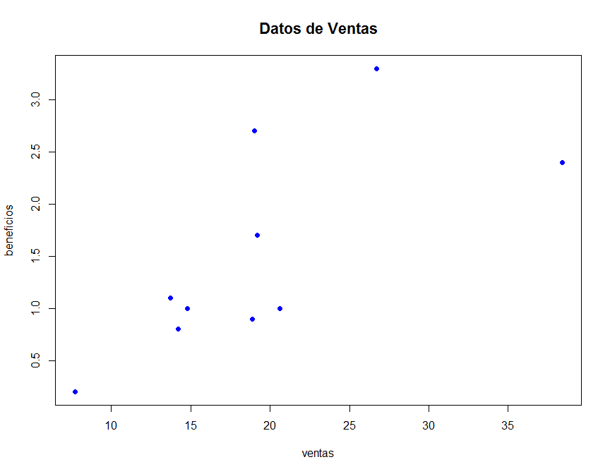

```r
plot(ventas,pch = 19,cex = 1,upper.panel = NULL, col = 4,
main = 'Datos de Ventas',cex.main = 1.4);
```